# Лабораторная работа 2

Неустроева.И.Н.

Российский университет дружбы народов, Москва, Россия

26.02.25

# Информация

## Докладчик

- Неустроева Ирина Николаевна
- студентка группы НБИ -02-23
- Российский университет дружбы народов

# Вводная часть

## Цели и задачи

- Получить практические навыки работы в консоли с атрибутами файлов, закрепить теоретические основы дискреционного разграничения доступа в современных системах с открытым кодом на базе ОС Linux

## Материалы и методы

- Процессор `pandoc` для входного формата Markdown
- Результирующие форматы
  - `pdf`
  - `html`
- Автоматизация процесса создания: `Makefile`

# Создание презентации

## Создание учетной записи

В установленной при выполнении предыдущей лабораторной работы операционнной системе создали учетную запись

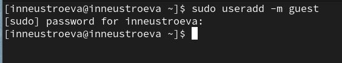

## Пароль

Далее задаем пароль для пользователя, который необходимо подтвердить, введя повторно.

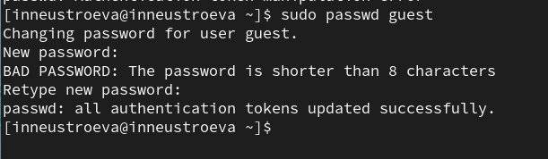

## Вход в систему и команда pwd

Вошли в систему от имени пользователя guest. Команда pwd помогает определить, что в данный момент мы находимся в домашней директории.

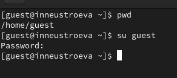

## whoami, Группы пользователя

С помощью команды whoami,которая выводит в терминал имя пользователя, от имени которого она была запущена. В нашем случае - guest. Узнать, в каких группах состоит пользователь, можно с помощью команды id (выводит idпользователя и его имя, id группы пользователя и ее названия). Либо воспользоваться командой groups, которая выводит только название группы.

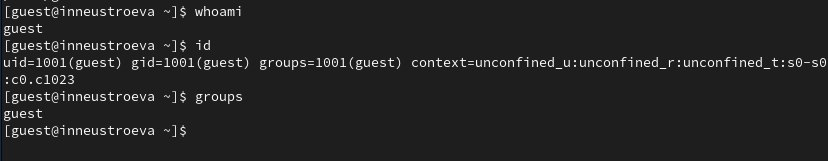

## Содержимое файла /etc/passwd

Запросив содержимое файла /etc/passwd командой cat мы можем видеть всех пользователей машины, их uid и gid. Либо использовать grep, для в качестве фильтра нужной нам строки. Для созданного пользователя uid и gid совпадают: 1001.

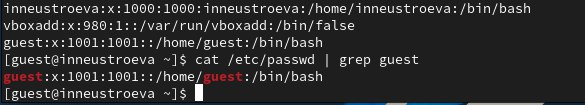

## Домашние директории пользователей

Командой ls -l /home/ определим существующие в системе домашние директории пользователей. Видим, что их две. В каждой из директорий владелец имеет право на чтение, запись и исполнение.

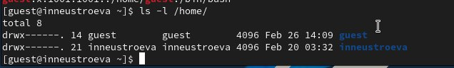

## Атрибуты директорий

С помощью lsattr можем, проверить, какие расширенные атрибуты установленны на поддериктрориях, расширенные атрибуты в своей директории нам удалось рассмотреть, а расширенные атрибуты других пользователей - нет

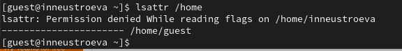

## Создание директории и права на нее

В домашней директории пользователя guest создадали директорию dir1. Можно увидеть, директория выдает все права владельцу и права на чтение и исполнение членам группы и прочим пользователям.

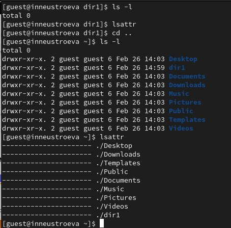

## Права для директории

Снимем все права с созданной нами директории. Можем видеть, что никто не имеет права ни на чтение, ни на запись, ни на исполнение файлов. Владелец в том числе.

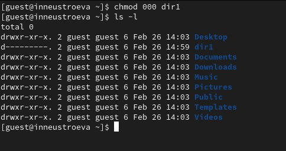

## Нет прав создать файл

При попытке создать файл внутри директории сталкнулись с ошибкой: на эту директорию у пользователя больше нет прав. С помощью ls -l еще раз удостоверелись, что файл не создался.

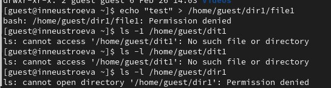

## Таблица

Права на каталог и файл в нем {#tbl:std-dir}

| Права директории | Права файла | Создание файла | Удаление файла | Запись в файл | Чтение файла | Смена директории | Просмотр файлов в директории | Переименование файла |
| --- | --- | --- | --- | --- | --- | --- | --- | --- |
| 000 | 000 | - | - | - | - | - | - | - |
| 100 | 000 | - | - | - | - | + | - | - |
| 200 | 000 | + | + | - | - | - | - | + |
| 300 | 000 | + | + | - | - | + | - | + |
| 400 | 000 | - | - | - | - | + | - | - |
| 500 | 000 | + | + | - | - | + | - | + |
| 600 | 000 | + | + | - | - | - | + | + |
| 700 | 000 | + | + | - | - | + | + | - |

## Таблица

100 | 200 | - | - | + | - | + | - | - | - |  
200 | 200 | + | + | + | - | - | - | + | - |  
300 | 200 | + | + | + | - | + | - | + | - |  
400 | 200 | - | - | + | - | + | + | - | + |  
500 | 200 | + | + | + | - | - | + | - | + |  
600 | 200 | + | + | + | - | - | + | + | + |  
700 | 200 | + | + | + | - | + | + | + | + |  
100 | 400 | - | - | - | - | + | - | - | - |  
200 | 400 | + | + | - | - | - | - | + | - |  
300 | 400 | + | + | - | - | + | - | + | - |  
400 | 400 | - | - | - | + | + | - | - | - |  
500 | 400 | + | + | - | + | + | - | + | - |

## Таблица

600 | 400 | + | + | - | + | - | + | + | - |  
700 | 400 | + | + | - | + | + | + | - | - |  
100 | 700 | - | - | - | - | + | - | - | - |  
200 | 700 | + | + | + | + | - | - | + | - |  
300 | 700 | + | + | + | + | + | - | + | - |  
400 | 700 | - | - | + | + | + | - | - | - |  
500 | 700 | - | - | + | + | + | + | - | + |  
600 | 700 | + | + | + | - | + | + | + | + |  
700 | 700 | + | + | + | + | + | + | + | + |

## Итог работы

Получили практические навыки работы в консоли с атрибутами файлов, закрепили теоретические основы дискреционного разграничения доступа в современных системах с открытым кодом на базе ОС Linux